# Project Assignment 2

Danuta Grabovska

2025-02-03

# Exercise 1

We begin from loading the data from course directory.

```r
www = "https://www.mimuw.edu.pl/~noble/courses/MultivariateStatistics/data/pendigits.txt"
pendigits <- read.table(www)
```

The data need a bit of preprocessing, such as extracting the 16 input variables and the class labels.

```r
X <- pendigits[, 1:16]
classes <- pendigits[, 17]
```

Now we can compute the variance of the 16 variables.

```r
var_vec <- sapply(X,var)
print(var_vec)
```

```
##        V1        V2        V3        V4        V5        V6        V7        V8
## 1173.5957  263.0420  693.9528  367.2453 1162.8451  728.8211  934.9457  894.3750
##        V9       V10       V11       V12       V13       V14       V15       V16
## 1165.2344  742.6469 1390.4013  735.4934  498.8763 1099.2847 1743.9310 1280.0720
```

## 2. Carry out PCA Using the Covariance Matrix

Since the variables have similar scales, we perform PCA on the centered data only.

```r
pca_cov <- prcomp(X, center = TRUE, scale. = FALSE)
summary(pca_cov)
```

```
## Importance of components:
##                            PC1     PC2     PC3      PC4      PC5      PC6
## Standard deviation     64.9131 60.8446 47.8075 36.62327 29.35851 26.80043
## Proportion of Variance  0.2833  0.2489  0.1537  0.09017  0.05795  0.04829
## Cumulative Proportion   0.2833  0.5322  0.6858  0.77599  0.83393  0.88222
##                             PC7      PC8      PC9     PC10     PC11     PC12
## Standard deviation     21.38547 19.93971 16.93488 14.29245 11.36052 10.01589
## Proportion of Variance  0.03075  0.02673  0.01928  0.01373  0.00868  0.00674
## Cumulative Proportion   0.91296  0.93969  0.95897  0.97271  0.98138  0.98813
##                           PC13    PC14    PC15    PC16
## Standard deviation     8.13346 7.66022 5.23502 4.93634
## Proportion of Variance 0.00445 0.00394 0.00184 0.00164
## Cumulative Proportion  0.99257 0.99652 0.99836 1.00000
```

## 3. How Many PCs Explain 80% and 90% of the Total Variation?

From the summary visible above, we can conclude that 5 components explain 83.39% of variance, while 7 components explain 91.30% of variance.

## 4. Display the First Three PCs Using Pairwise Scatterplots

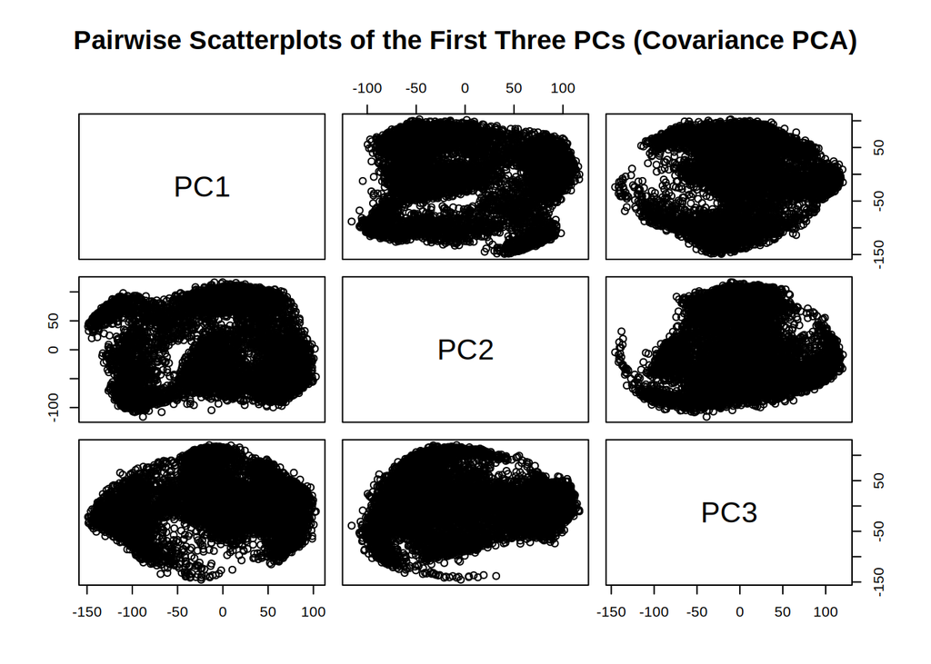

```r
pairs(pca_cov$x[, 1:3],
      main = "Pairwise Scatterplots of the First Three PCs (Covariance PCA)",
      labels = c("PC1", "PC2", "PC3"))
```

## 5. Carry out PCA Using the Correlation Matrix

Here we scale the variables so that PCA is based on the correlation matrix.

```r
pca_cor <- prcomp(X, center = TRUE, scale. = TRUE)
summary(pca_cor)
```

```
## Importance of components:
##                           PC1    PC2    PC3     PC4     PC5     PC6     PC7
## Standard deviation     2.1718 1.7970 1.6052 1.10894 1.03107 0.89294 0.77888
## Proportion of Variance 0.2948 0.2018 0.1610 0.07686 0.06644 0.04983 0.03792
## Cumulative Proportion  0.2948 0.4966 0.6577 0.73452 0.80096 0.85079 0.88871
##                            PC8     PC9    PC10    PC11    PC12    PC13    PC14
## Standard deviation     0.74044 0.64096 0.54611 0.45882 0.33511 0.28369 0.24084
## Proportion of Variance 0.03427 0.02568 0.01864 0.01316 0.00702 0.00503 0.00363
## Cumulative Proportion  0.92297 0.94865 0.96729 0.98045 0.98747 0.99250 0.99612
##                           PC15    PC16
## Standard deviation     0.18511 0.16673
## Proportion of Variance 0.00214 0.00174
## Cumulative Proportion  0.99826 1.00000
```

# 6. Draw the Scree Plots for PCA (Covariance and Correlation)

First we draw a Scree plot for PCA using the covariance matrix.

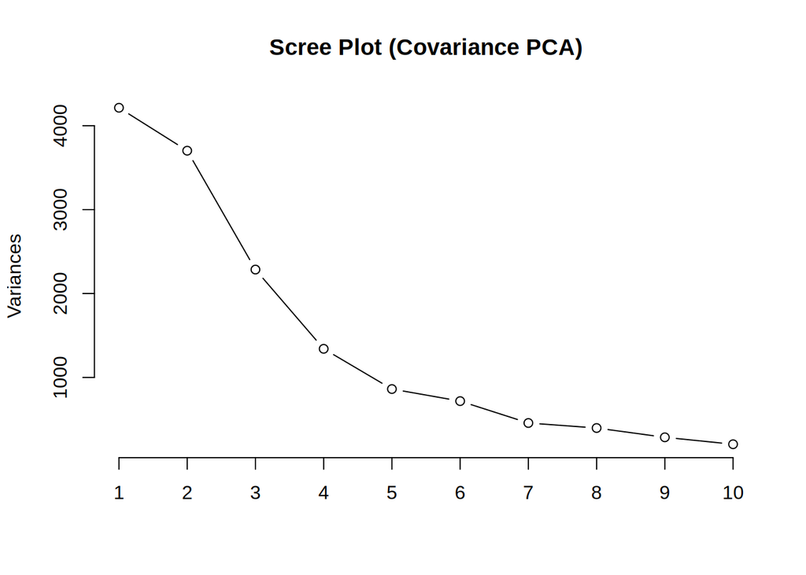

```r
screeplot(pca_cov, type = "lines", main = "Scree Plot (Covariance PCA)")
```

In this case I would use 5 or 7 principal components.

Then we can draw a Scree plot for PCA using the correlation matrix.

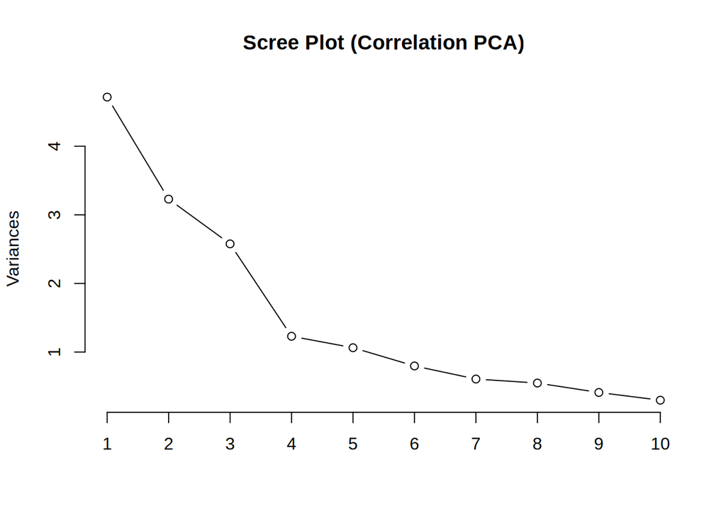

```r
screeplot(pca_cor, type = "lines", main = "Scree Plot (Correlation PCA)")
```

Here I would use 4 or 7 principal components.

## 7. Is There Ill-Conditioning in the Data Matrix?

One way to assess ill-conditioning is to examine the condition number. A common measure is the ratio of the largest to the smallest eigenvalue.

```r
eigen_cov <- pca_cov$sdev^2
cond_number <- max(eigen_cov) / min(eigen_cov)
cat("Condition number (Covariance PCA):", cond_number, "\n")
```

```
## Condition number (Covariance PCA): 172.9239
```

The condition number we got is equal to 172.9239, which, taking the covariance spread between 24.36 and 4213.71 into consideration, is not too much. We can assume there is some moderate ill-conditioning. However, considering the fact that none of the principal components is degenerate, the occuring ill-conditioning is rather acceptable.

# Exercise 2

We begin from loading the data from course directory.

```r
www2 = "https://www.mimuw.edu.pl/~noble/courses/MultivariateStatistics/data/ozone.csv"
ozone <- read.csv(www2)
```

Let’s have a look into the dataset.

```r
head(ozone)
```

```
##   Station   Av8top      Lat       Lon
## 1      60 7.225806 34.13583 -117.9236
## 2      69 5.899194 34.17611 -118.3153
## 3      72 4.052885 33.82361 -118.1875
## 4      74 7.181452 34.19944 -118.5347
## 5      75 6.076613 34.06694 -117.7514
## 6      84 3.157258 33.92917 -118.2097
```

To perform a Mantel test, we need the matrices of the distances between stations and difference in ozone measurements.

```r
station.dists <- dist(cbind(ozone$Lon, ozone$Lat))
ozone.dists <- dist(ozone$Av8top)
as.matrix(station.dists)[1:5, 1:5]
```

```
##           1         2         3         4         5
## 1 0.0000000 0.3937326 0.4088031 0.6144127 0.1854888
## 2 0.3937326 0.0000000 0.3749446 0.2206810 0.5743590
## 3 0.4088031 0.3749446 0.0000000 0.5116772 0.4994034
## 4 0.6144127 0.2206810 0.5116772 0.0000000 0.7944601
## 5 0.1854888 0.5743590 0.4994034 0.7944601 0.0000000
```

```r
as.matrix(ozone.dists)[1:5, 1:5]
```

```
##          1        2        3        4        5
## 1 0.000000 1.326612 3.172921 0.044354 1.149193
## 2 1.326612 0.000000 1.846309 1.282258 0.177419
## 3 3.172921 1.846309 0.000000 3.128567 2.023728
## 4 0.044354 1.282258 3.128567 0.000000 1.104839
## 5 1.149193 0.177419 2.023728 1.104839 0.000000
```

Now we can perform the Mantel test to check our hypothesis.

```r
mantel.rtest(station.dists, ozone.dists, nrepet = 9999)
```

```
## Monte-Carlo test
## Call: mantel.rtest(m1 = station.dists, m2 = ozone.dists, nrepet = 9999)
##
## Observation: 0.1636308
##
## Based on 9999 replicates
## Simulated p-value: 0.029
## Alternative hypothesis: greater
##
##      Std.Obs  Expectation     Variance
## 2.2174476261 0.0002802506 0.0054266827
```

Since we have statistically significant positive correlation between geographic distance and ozone difference, we can assume that indeed, the differences between ozone measurements are smaller for stations that are closer together.

# Exercise 3

We begin from loading the data from course directory.

```r
www3 = "https://www.mimuw.edu.pl/~noble/courses/MultivariateStatistics/data/primate.scapulae.xlsx"
primate_data <- import(www3)
```

Then, before doind any clustering, we need to extract the 7 variables available for all specimens: indices AD.BD, AD.CD, EA.CD, Dx.CD, SH.ACR, as well as angles EAD and beta.

```r
primate_subset <- primate_data[, 2:8]
```

Since we wish to cluster the variables, we first standardize each variable.

```r
primate_scaled <- scale(primate_subset)
```

First we want to cluster variables. With data in the usual format (observations in rows, variables in columns) we need to transpose so that each row corresponds to one variable.

```r
var_matrix <- t(primate_scaled)
```

Now, each row of var_matrix is one of the 7 variables.

Before clustering, we need to compute the distance matrix between variables using Euclidean distance:

```r
d <- dist(var_matrix, method = "euclidean")
```

We’ll start from hierarchical clustering with following linkage methods and corresponding dendrograms:

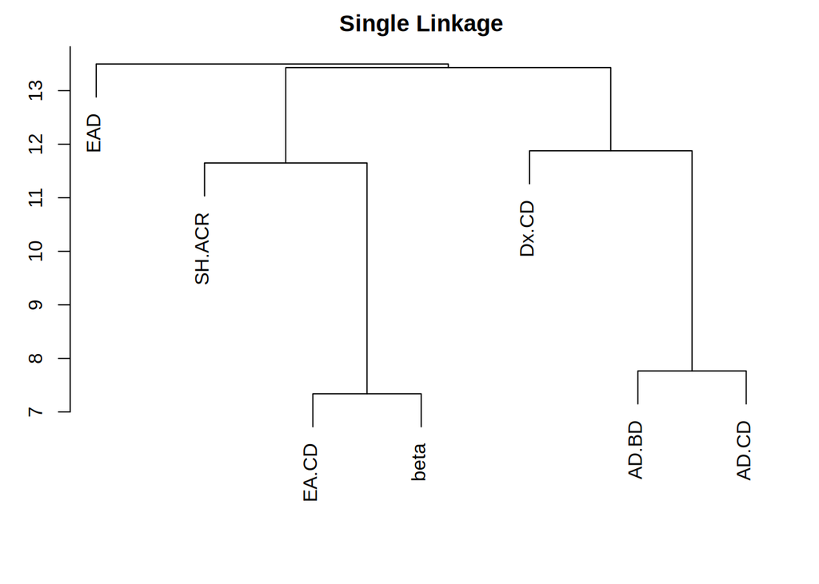

```r
par(mar = c(3, 3, 2, 2))
#Single Linkage
hc_single <- hclust(d, method = "single")
plot(hc_single, main = "Single Linkage",
     sub = "", xlab = "", ylab = "Euclidean distance")
```

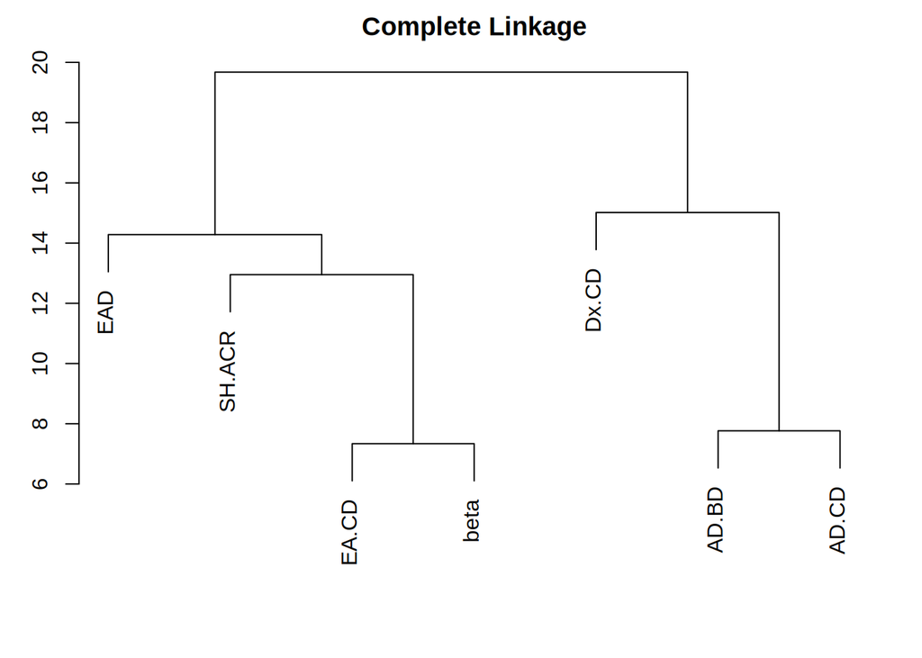

```r
#Complete Linkage
hc_complete <- hclust(d, method = "complete")
plot(hc_complete, main = "Complete Linkage",
     sub = "", xlab = "", ylab = "Euclidean distance")
```

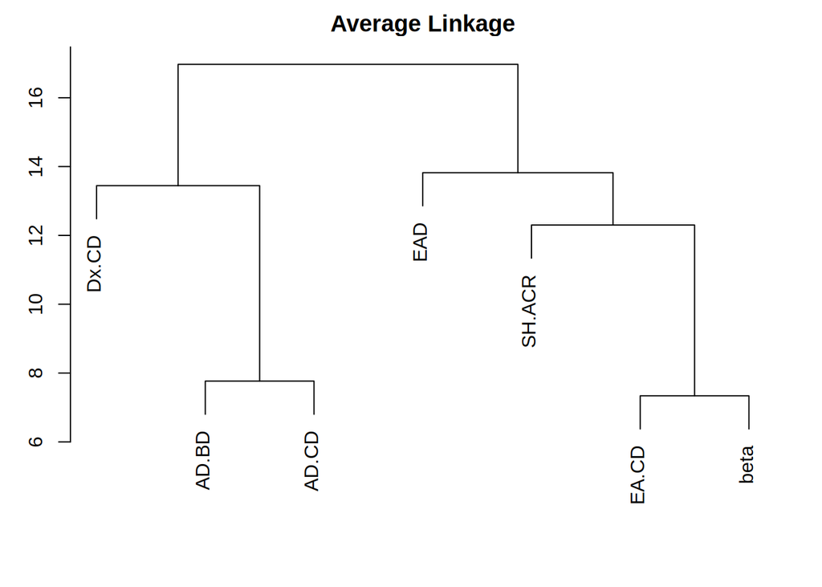

```r
#Average Linkage
hc_average <- hclust(d, method = "average")
plot(hc_average, main = "Average Linkage",
     sub = "", xlab = "", ylab = "Euclidean distance")
```

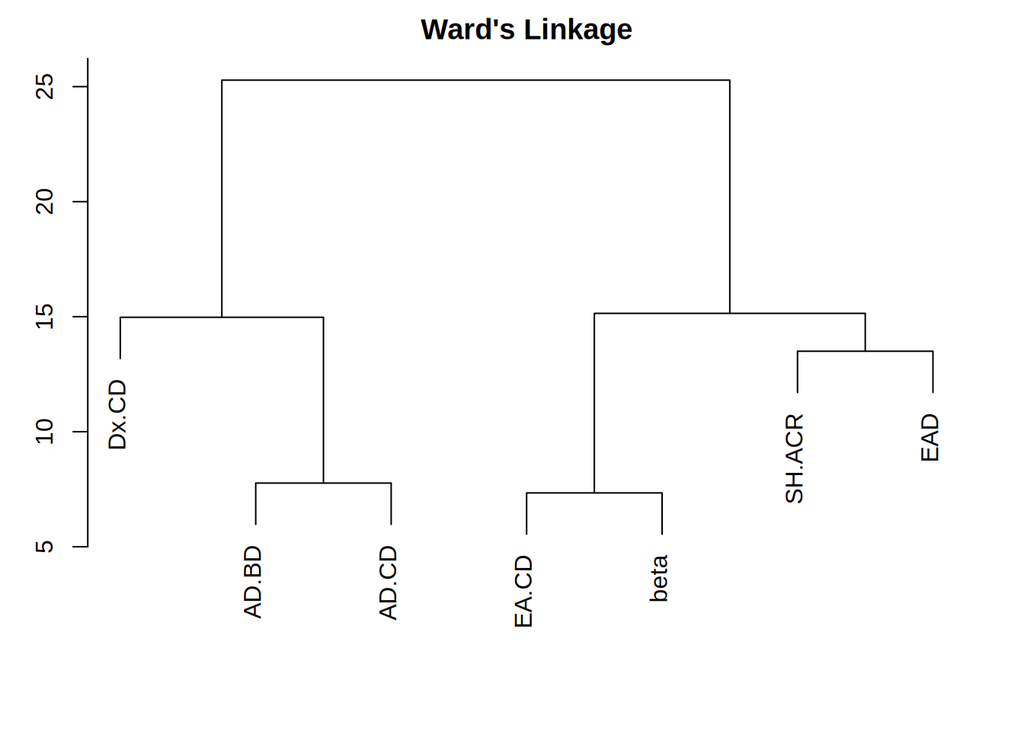

```r
#Ward's Linkage
hc_ward <- hclust(d, method = "ward.D2")
plot(hc_ward, main = "Ward's Linkage",
     sub = "", xlab = "", ylab = "Euclidean distance")
```

In the single linkage dendrogram, we can see that EAD variable joins the cluster quite late and can be considered an outlier. The other dendrograms tend to be quite balanced.

Now let’s consider divisive clustering using DIANA.

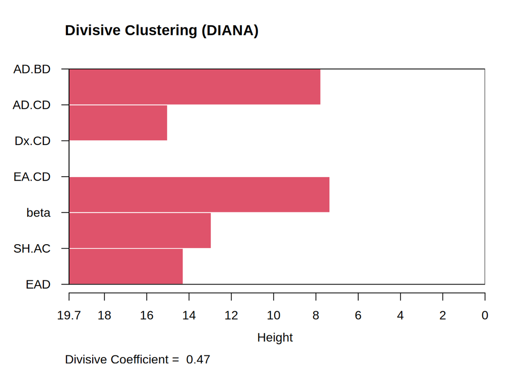

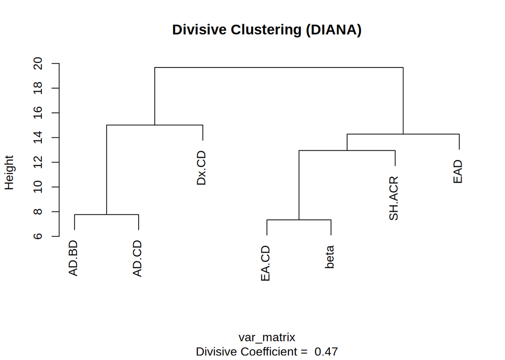

```r
diana_res <- diana(var_matrix)
par(mfrow = c(1,1))
plot(diana_res, main = "Divisive Clustering (DIANA)")
```

This dendrogram is also rather pleasantly balanced.

Now we can move on to the clustering of actual observations.

First, we compute the distance matrix among observations:

```r
d_obs <- dist(primate_scaled, method = "euclidean")
```

Now we cluster the observations using beforementioned methods and cut the dendrograms to obtain 5 clusters:

```r
hc_single_obs   <- hclust(d_obs, method = "single")
hc_complete_obs <- hclust(d_obs, method = "complete")
hc_average_obs  <- hclust(d_obs, method = "average")
hc_ward_obs     <- hclust(d_obs, method = "ward.D2")

diana_res <- diana(primate_scaled)
hc_diana_obs <- as.hclust(diana_res)

clusters_single   <- cutree(hc_single_obs,   k = 5)
clusters_complete <- cutree(hc_complete_obs, k = 5)
clusters_average  <- cutree(hc_average_obs,  k = 5)
clusters_ward     <- cutree(hc_ward_obs,     k = 5)
clusters_diana    <- cutree(hc_diana_obs,    k = 5)
```

To compute misclassification rate, we’ll define a function which creates the contingency table and sums the counts of the majority class in each cluster.

```r
misclass_rate <- function(true_labels, cluster_assignments) {
  tab <- table(true_labels, cluster_assignments)
  majority_counts <- apply(tab, 2, max)
  total_majority <- sum(majority_counts)
  total_obs <- length(true_labels)
  rate <- 1 - total_majority / total_obs
  return(rate)
}
```

Now we apply the function to compute confusion tables and misclassification rates for each method.

```r
species <- primate_data$classdigit
# Single Linkage
conf_single <- table(Species = species, Cluster = clusters_single)
mis_single <- misclass_rate(species, clusters_single)
cat("Single Linkage:\n")
```

```
## Single Linkage:
```

```r
print(conf_single)
```

```
##        Cluster
## Species  1  2  3  4  5
##       1 16  0  0  0  0
##       2  0 13  1  1  0
##       3 20  0  0  0  0
##       4 14  0  0  0  0
##       5  0 39  0  0  1
```

```r
cat("Misclassification Rate:", mis_single, "\n\n")
```

```
## Misclassification Rate: 0.4095238
```

```r
# Complete Linkage
conf_complete <- table(Species = species, Cluster = clusters_complete)
mis_complete <- misclass_rate(species, clusters_complete)
cat("Complete Linkage:\n")
```

```
## Complete Linkage:
```

```r
print(conf_complete)
```

```
##        Cluster
## Species  1  2  3  4  5
##       1 14  2  0  0  0
##       2  0  2 13  0  0
##       3  0  0  0 20  0
##       4  0  0  0 14  0
##       5  0  4  1  0 35
```

```r
cat("Misclassification Rate:", mis_complete, "\n\n")
```

```
## Misclassification Rate: 0.1809524
```

```r
# Average Linkage
conf_average <- table(Species = species, Cluster = clusters_average)
mis_average <- misclass_rate(species, clusters_average)
cat("Average Linkage:\n")
```

```
## Average Linkage:
```

```r
print(conf_average)
```

```
##        Cluster
## Species  1  2  3  4  5
##       1 16  0  0  0  0
##       2  0 13  1  1  0
##       3  0  0  0  0 20
##       4  0  0  0  0 14
##       5  0 36  0  4  0
```

```r
cat("Misclassification Rate:", mis_average, "\n\n")
```

```
## Misclassification Rate: 0.2666667
```

```r
# Ward's Linkage
conf_ward <- table(Species = species, Cluster = clusters_ward)
mis_ward <- misclass_rate(species, clusters_ward)
cat("Ward's Linkage:\n")
```

```
## Ward's Linkage:
```

```r
print(conf_ward)
```

```
##        Cluster
## Species  1  2  3  4  5
##       1 16  0  0  0  0
##       2  0 14  1  0  0
##       3  0  0  0 20  0
##       4  0  0  0 14  0
##       5  0  3  3  0 34
```

```r
cat("Misclassification Rate:", mis_ward, "\n\n")
```

```
## Misclassification Rate: 0.1714286
```

```r
# Divisive Clustering (DIANA)
conf_diana <- table(Species = species, Cluster = clusters_diana)
mis_diana <- misclass_rate(species, clusters_diana)
cat("Divisive Clustering (DIANA):\n")
```

```
## Divisive Clustering (DIANA):
```

```r
print(conf_diana)
```

```
##        Cluster
## Species  1  2  3  4  5
##       1 16  0  0  0  0
##       2  0 15  0  0  0
##       3  0  0 20  0  0
##       4  0  0 14  0  0
##       5  0  1  0 16 23
```

```r
cat("Misclassification Rate:", mis_diana, "\n\n")
```

```
## Misclassification Rate: 0.1428571
```

The most impressive result with the lowest misclassification rate was achieved by divisive clustering, while the highest rate (with quite a landslide) was given by single linkage.

# Exercise 4

We begin from loading the data from the AER library.

```r
data(DoctorVisits)
```

We shall start from using a Poisson regression for the number of visits.

```r
dv_pois <- glm(visits~.,data=DoctorVisits, family=poisson)
summary(dv_pois)
```

```
##
## Call:
## glm(formula = visits ~ ., family = poisson, data = DoctorVisits)
##
## Coefficients:
##               Estimate Std. Error z value Pr(>|z|)
## (Intercept)  -2.097821   0.101554 -20.657  < 2e-16 ***
## genderfemale  0.156490   0.056139   2.788  0.00531 **
## age           0.279123   0.165981   1.682  0.09264 .
## income       -0.187416   0.085478  -2.193  0.02834 *
## illness       0.186156   0.018263  10.193  < 2e-16 ***
## reduced       0.126690   0.005031  25.184  < 2e-16 ***
## health        0.030683   0.010074   3.046  0.00232 **
## privateyes    0.126498   0.071552   1.768  0.07707 .
## freepooryes  -0.438462   0.179799  -2.439  0.01474 *
## freerepatyes  0.083640   0.092070   0.908  0.36365
## nchronicyes   0.117300   0.066545   1.763  0.07795 .
## lchronicyes   0.150717   0.082260   1.832  0.06692 .
## ---
## Signif. codes:  0 '***' 0.001 '**' 0.01 '*' 0.05 '.' 0.1 ' ' 1
##
## (Dispersion parameter for poisson family taken to be 1)
##
##     Null deviance: 5634.8  on 5189  degrees of freedom
## Residual deviance: 4380.1  on 5178  degrees of freedom
## AIC: 6735.7
##
## Number of Fisher Scoring iterations: 6
```

The AIC result is… rather underwhelming. We may suspect some overdispersion, so let’s check for it:

```r
disp_test <- dispersiontest(dv_pois)
print(disp_test)
```

```
##
##  Overdispersion test
##
## data:  dv_pois
## z = 6.5386, p-value = 3.105e-11
## alternative hypothesis: true dispersion is greater than 1
## sample estimates:
## dispersion
##   1.415602
```

Indeed, the overdispersion is present, therefore we should try other models.

```r
dv_nb <- glm.nb(visits~.,data=DoctorVisits)
summary(dv_nb)
```

```
##
## Call:
## glm.nb(formula = visits ~ ., data = DoctorVisits, init.theta = 0.9301535861,
##     link = log)
##
## Coefficients:
##               Estimate Std. Error z value Pr(>|z|)
## (Intercept)  -2.276138   0.122749 -18.543  < 2e-16 ***
## genderfemale  0.216333   0.069681   3.105  0.00191 **
## age           0.331326   0.207755   1.595  0.11076
## income       -0.156214   0.103907  -1.503  0.13273
## illness       0.214937   0.023521   9.138  < 2e-16 ***
## reduced       0.143729   0.007305  19.674  < 2e-16 ***
## health        0.037535   0.013609   2.758  0.00581 **
## privateyes    0.116379   0.085666   1.359  0.17430
## freepooryes  -0.497256   0.210696  -2.360  0.01827 *
## freerepatyes  0.145683   0.115851   1.258  0.20857
## nchronicyes   0.097905   0.079153   1.237  0.21612
## lchronicyes   0.183473   0.103176   1.778  0.07536 .
## ---
## Signif. codes:  0 '***' 0.001 '**' 0.01 '*' 0.05 '.' 0.1 ' ' 1
##
## (Dispersion parameter for Negative Binomial(0.9302) family taken to be 1)
##
##     Null deviance: 3930.4  on 5189  degrees of freedom
## Residual deviance: 3029.8  on 5178  degrees of freedom
## AIC: 6423.7
##
## Number of Fisher Scoring iterations: 1
##
##
##               Theta:  0.9302
##           Std. Err.:  0.0867
##
##  2 x log-likelihood:  -6397.6760
```

The shape parameter theta estimate is 0.9302, suggesting considerable overdispersion.

We may check for other issues, for example proportions of zeros to the total amount of observations:

```r
zero_freq <- sum(DoctorVisits$visits == 0)
total_obs <- nrow(DoctorVisits)
cat("Proportion of zeros:", zero_freq / total_obs, "\n")
```

```
## Proportion of zeros: 0.7978805
```

That is quite large - we should consider using a zero-inflated model, both Poisson and negative binomial one.

```r
dv_zip <- zeroinfl(visits~.,data=DoctorVisits, dist = "poisson")
summary(dv_zip)
```

```
##
## Call:
## zeroinfl(formula = visits ~ ., data = DoctorVisits, dist = "poisson")
##
## Pearson residuals:
##     Min      1Q  Median      3Q     Max
## -1.5991 -0.4452 -0.2880 -0.1896 11.5788
##
## Count model coefficients (poisson with log link):
##               Estimate Std. Error z value Pr(>|z|)
## (Intercept)  -0.549676   0.143841  -3.821 0.000133 ***
## genderfemale -0.020146   0.071572  -0.281 0.778346
## age          -0.002362   0.217525  -0.011 0.991335
## income       -0.214097   0.109938  -1.947 0.051484 .
## illness       0.044164   0.024656   1.791 0.073259 .
## reduced       0.082782   0.005993  13.813  < 2e-16 ***
## health        0.022712   0.011261   2.017 0.043708 *
## privateyes   -0.021792   0.096733  -0.225 0.821760
## freepooryes  -0.382335   0.241160  -1.585 0.112875
## freerepatyes -0.211981   0.118573  -1.788 0.073813 .
## nchronicyes  -0.011808   0.092675  -0.127 0.898612
## lchronicyes   0.001586   0.102220   0.016 0.987622
##
## Zero-inflation model coefficients (binomial with logit link):
##              Estimate Std. Error z value Pr(>|z|)
## (Intercept)   2.59902    0.29413   8.836  < 2e-16 ***
## genderfemale -0.45847    0.17082  -2.684  0.00728 **
## age          -1.31174    0.51221  -2.561  0.01044 *
## income       -0.07151    0.24158  -0.296  0.76722
## illness      -0.44176    0.08320  -5.309 1.10e-07 ***
## reduced      -1.24858    0.23896  -5.225 1.74e-07 ***
## health       -0.07919    0.03876  -2.043  0.04104 *
## privateyes   -0.42977    0.19703  -2.181  0.02917 *
## freepooryes   0.31230    0.51329   0.608  0.54289
## freerepatyes -1.25152    0.31946  -3.918 8.94e-05 ***
## nchronicyes  -0.11607    0.19917  -0.583  0.56004
## lchronicyes  -0.44749    0.30581  -1.463  0.14339
## ---
## Signif. codes:  0 '***' 0.001 '**' 0.01 '*' 0.05 '.' 0.1 ' ' 1
##
## Number of iterations in BFGS optimization: 43
## Log-likelihood: -3181 on 24 Df
```

```r
dv_zinb <- zeroinfl(visits~.,data=DoctorVisits, dist = "negbin")
summary(dv_zinb)
```

```
##
## Call:
## zeroinfl(formula = visits ~ ., data = DoctorVisits, dist = "negbin")
##
## Pearson residuals:
##     Min      1Q  Median      3Q     Max
## -1.0320 -0.4491 -0.2890 -0.1680 12.7623
##
## Count model coefficients (negbin with log link):
##               Estimate Std. Error z value Pr(>|z|)
## (Intercept)  -0.959296   0.180126  -5.326 1.01e-07 ***
## genderfemale  0.022514   0.083614   0.269 0.787732
## age           0.136253   0.269325   0.506 0.612924
## income       -0.139739   0.127430  -1.097 0.272819
## illness       0.050282   0.029199   1.722 0.085056 .
## reduced       0.105181   0.007848  13.401  < 2e-16 ***
## health        0.026820   0.013711   1.956 0.050455 .
## privateyes   -0.095854   0.114182  -0.839 0.401196
## freepooryes  -0.498608   0.282069  -1.768 0.077115 .
## freerepatyes -0.194325   0.141548  -1.373 0.169798
## nchronicyes  -0.001614   0.107748  -0.015 0.988049
## lchronicyes   0.078434   0.119293   0.657 0.510865
## Log(theta)    0.515091   0.135067   3.814 0.000137 ***
##
## Zero-inflation model coefficients (binomial with logit link):
##              Estimate Std. Error z value Pr(>|z|)
## (Intercept)   2.41310    0.39305   6.139 8.28e-10 ***
## genderfemale -0.55851    0.23019  -2.426  0.01525 *
## age          -1.36053    0.74178  -1.834  0.06663 .
## income        0.06931    0.31468   0.220  0.82568
## illness      -0.72059    0.15786  -4.565 5.00e-06 ***
## reduced      -1.85307    0.74200  -2.497  0.01251 *
## health       -0.09003    0.05916  -1.522  0.12805
## privateyes   -0.67539    0.26723  -2.527  0.01149 *
## freepooryes   0.09407    0.67855   0.139  0.88974
## freerepatyes -1.56989    0.49466  -3.174  0.00151 **
## nchronicyes  -0.11577    0.28350  -0.408  0.68301
## lchronicyes  -0.35730    0.42656  -0.838  0.40225
## ---
## Signif. codes:  0 '***' 0.001 '**' 0.01 '*' 0.05 '.' 0.1 ' ' 1
##
## Theta = 1.6738
## Number of iterations in BFGS optimization: 48
## Log-likelihood: -3111 on 25 Df
```

Now we can compare models via AIC measure.

```r
AIC_pois <- AIC(dv_pois)
AIC_nb   <- AIC(dv_nb)
AIC_zip  <- AIC(dv_zip)
AIC_zinb  <- AIC(dv_zinb)

cat("AIC (Poisson):", AIC_pois, "\n")
```

```
## AIC (Poisson): 6735.701
```

```r
cat("AIC (Negative Binomial):", AIC_nb, "\n")
```

```
## AIC (Negative Binomial): 6423.676
```

```r
cat("AIC (Zero-Inflated Poisson Model):", AIC_zip, "\n")
```

```
## AIC (Zero-Inflated Poisson Model): 6409.854
```

```r
cat("AIC (Zero-Inflated Negative Binomial Model):", AIC_zinb, "\n")
```

```
## AIC (Zero-Inflated Negative Binomial Model): 6272.766
```

We can clearly see that Zero-Inflated Negative Binomial Model is by far the best, proving the beforementioned considerations right.

#Exercise 5 As there were issues from importing the file using URL, we’ll load it from a local file:

```r
load("/home/sool/Downloads/color.stimuli.rda")
```

We’ll start from creating a dissimilarity matrix:

```r
dissim <- 1 - color.stimuli
```

Now we conduct a metric MDS and plot it:

```r
mds_classic <- cmdscale(dissim, k = 2)
print(mds_classic)
```

```
##            [,1]        [,2]
## w434 -0.2137161 -0.41852576
## w445 -0.2562012 -0.41065436
## w465 -0.4119890 -0.30925977
## w472 -0.4369586 -0.27266935
## w490 -0.4388604  0.07518594
## w504 -0.3364868  0.37262279
## w537 -0.2429950  0.47735969
## w555 -0.1893125  0.48826989
## w584  0.2418131  0.29739050
## w600  0.4016882  0.15279550
## w610  0.4986351 -0.02861306
## w628  0.4956801 -0.10485148
## w651  0.4582372 -0.14801944
## w674  0.4304660 -0.17103108
```

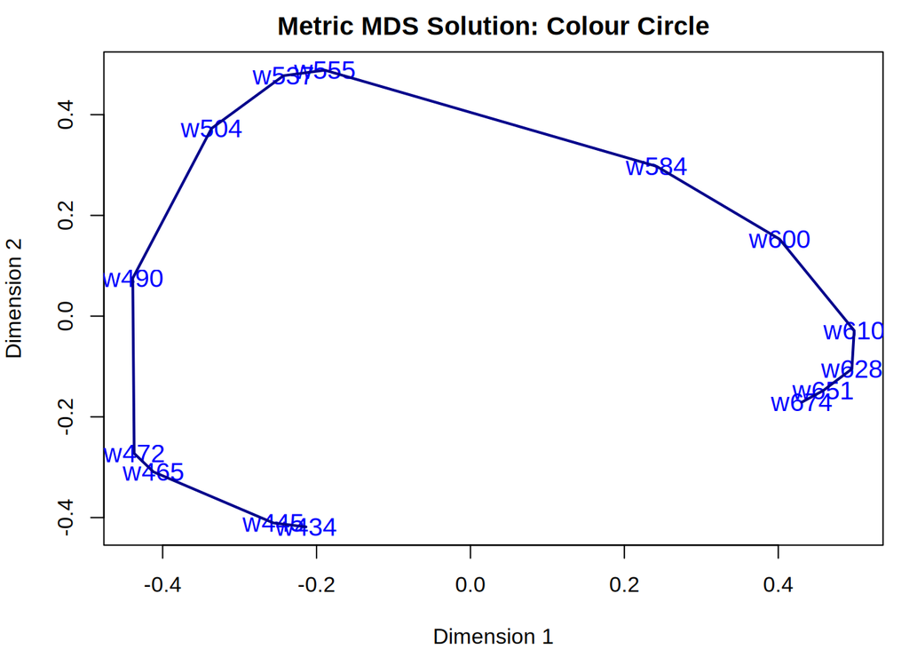

```r
ord <- order(rownames(mds_classic))
par(mfrow = c(1,1), mar = c(4,4,2,1))
plot(mds_classic, type = "n",
     main = "Metric MDS Solution: Colour Circle",
     xlab = "Dimension 1", ylab = "Dimension 2")
text(mds_classic, labels = rownames(mds_classic), col = "blue", cex = 1.2)
# Connect points in the order of increasing wavelength:
lines(mds_classic[ord, ], col = "darkblue", lwd = 2)
```

We can clearly see a nearly circular arrangement. What about a non-metric scaling?

```r
mds_nonmetric <- isoMDS(dissim, k = 2, trace = TRUE)
print(mds_nonmetric$points)
```

```
##            [,1]        [,2]
## w434 -0.1915460 -0.48024550
## w445 -0.2351617 -0.45487371
## w465 -0.4996787 -0.29155836
## w472 -0.5375009 -0.26025207
## w490 -0.5603725  0.08560858
## w504 -0.4410210  0.38470907
## w537 -0.3079628  0.50083625
## w555 -0.1683625  0.56166589
## w584  0.3206624  0.39639602
## w600  0.4829545  0.19761056
## w610  0.5664969 -0.01400424
## w628  0.5557180 -0.13277919
## w651  0.5308177 -0.20348299
## w674  0.4849566 -0.28963032
```

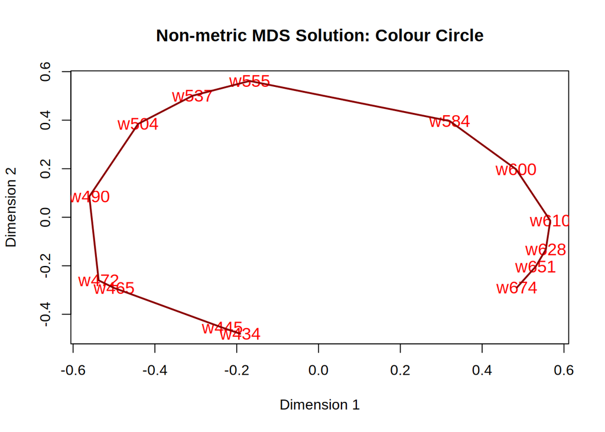

```r
plot(mds_nonmetric$points, type = "n",
     main = "Non-metric MDS Solution: Colour Circle",
     xlab = "Dimension 1", ylab = "Dimension 2")
text(mds_nonmetric$points, labels = rownames(mds_classic), col = "red", cex = 1.2)
lines(mds_nonmetric$points[ord, ], col = "darkred", lwd = 2)
```

As we can see, there is very little difference between metric and non-metric scaling solution. We can therefore conclude that the data are consistent with a continuous perceptual dimension of hue.

# Exercise 6

As there were issues from importing the file using URL, we’ll load it from a local file:

```r
load("/home/sool/Downloads/wdbc.rda")
```

In order to be able to use different number of variables selected as candidates for splitting and number of bootstrap trees in the forest, we shall define a following grid:

```r
mtry_values <- c(2, 4, 6, 8, 10)
ntree_values <- c(100, 500, 1000, 1500)
replications <- 1:100
param_grid <- expand.grid(mtry = mtry_values, ntree = ntree_values, seed = replications)
```

Due to slightly higher computational complexity of this task, we set up a parallel background:

```r
numCores <- detectCores() - 1
cl <- makeCluster(numCores)
registerDoParallel(cl)
```

Now we’re able to run a loop for 100 replications and every value in our grid.

```r
results <- foreach(i = 1:nrow(param_grid), .combine = rbind,
                   .packages = c("caret", "randomForest")) %dopar% {

                     this_row <- param_grid[i, ]
                     current_mtry <- this_row$mtry
                     current_ntree <- this_row$ntree
                     current_seed <- this_row$seed

                     # Set a unique seed for each repetition
                     set.seed(1000 * current_mtry + current_ntree + current_seed)

                     # Define trainControl to train the model on the full data
                     tc <- trainControl(method = "none")

                     # Train the random forest model
                     model <- train(class ~ .,
                                    data = wdbc,
                                    method = "rf",
                                    tuneGrid = data.frame(mtry = current_mtry),
                                    ntree = current_ntree,
                                    trControl = tc)

                     # Extract the OOB error from the final model.
                     oob_error <- model$finalModel$err.rate[current_ntree, "OOB"]

                     # Return a data frame with the parameters and the OOB error.
                     data.frame(mtry = current_mtry,
                                ntree = current_ntree,
                                seed = current_seed,
                                oob_error = oob_error)
                   }
# Stop the parallel cluster
stopCluster(cl)
```

Now we cal visualize the results:

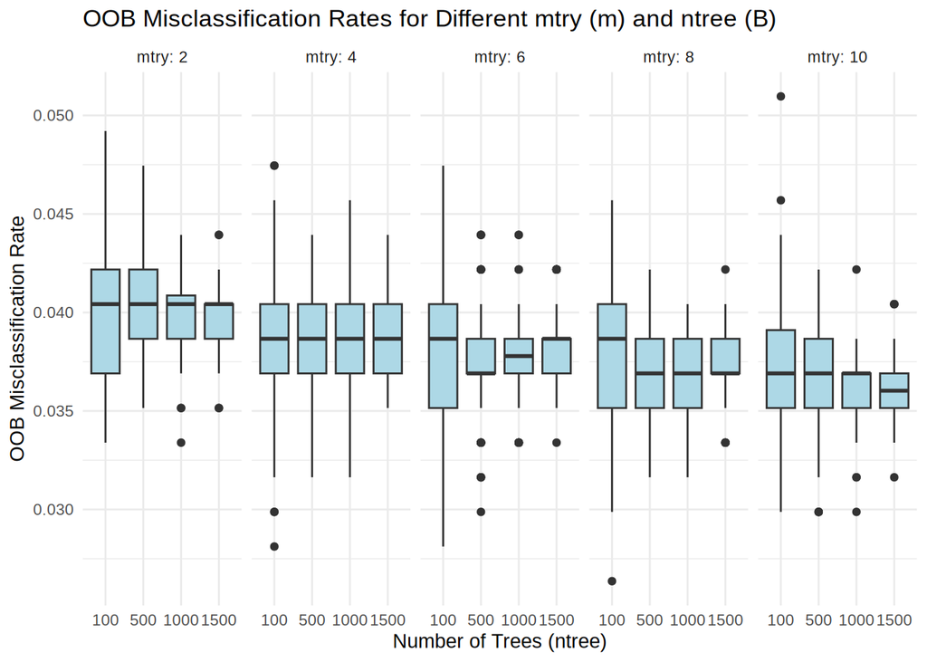

```r
ggplot(results, aes(x = factor(ntree), y = oob_error)) +
  geom_boxplot(fill = "lightblue") +
  facet_wrap(~ mtry, nrow = 1, labeller = label_both) +
  labs(x = "Number of Trees (ntree)",
       y = "OOB Misclassification Rate",
       title = "OOB Misclassification Rates for Different mtry (m) and ntree (B)") +
  theme_minimal()
```

Before performing batch-SOM analysis, we need some data preprocessing:

```r
data_features <- wdbc[, setdiff(names(wdbc), "class")]
data_class    <- wdbc$class
data_scaled <- scale(data_features)
```

Now we can create a grid and perform SOM analysis:

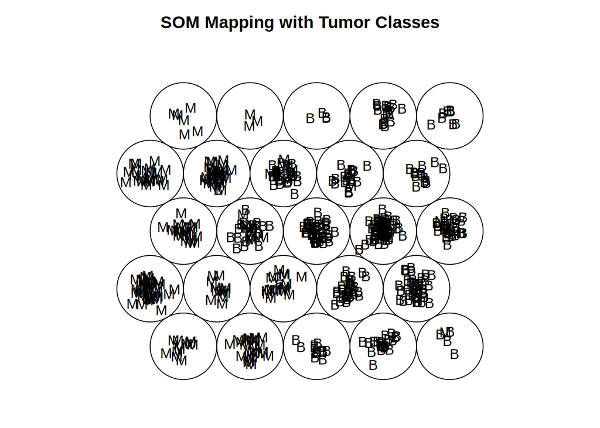

```r
som_grid <- somgrid(xdim = 5, ydim = 5, topo = "hexagonal", toroidal = TRUE)
set.seed(123)
som_model <- som(data_scaled,
                 grid = som_grid,
                 rlen = 100,
                 mode = "batch",
                 keep.data = TRUE)
plot(som_model, type = "mapping",
     labels = as.character(data_class),
     main = "SOM Mapping with Tumor Classes")
```

To assess the quality of the clustering, we may first create a contingency table comparing the true class labels to the SOM node assignments:

```r
node_assignments <- som_model$unit.classif  # vector of node numbers for each observation
class_table <- table(Class = data_class, SOM_Node = node_assignments)
print(class_table)
```

```
##      SOM_Node
## Class  1  2  3  4  5  6  7  8  9 10 11 12 13 14 15 16 17 18 19 20 21 22 23 24
##     B  0  0 12 21  4  0  0  1 33 40  0 19 45 63 30  0  2 25 20 14  0  0  4 16
##     M 12 26  0  0  1 38 13 18  0  0 21  9  0  0  2 23 32  7  1  0  6  3  0  0
##      SOM_Node
## Class 25
##     B  8
##     M  0
```

We may also compute a simple “purity” measure for each SOM node, identifying the majority class and computing the proportion of cases in that node that belong to that class.

```r
purity_by_node <- sapply(split(data_class, node_assignments), function(classes) {
  majority_count <- max(table(classes))
  purity <- majority_count / length(classes)
  return(purity)
})
cat("Purity of each SOM node:\n")
```

```
## Purity of each SOM node:
```

```r
print(purity_by_node)
```

```
##         1         2         3         4         5         6         7         8
## 1.0000000 1.0000000 1.0000000 1.0000000 0.8000000 1.0000000 1.0000000 0.9473684
##         9        10        11        12        13        14        15        16
## 1.0000000 1.0000000 1.0000000 0.6785714 1.0000000 1.0000000 0.9375000 1.0000000
##        17        18        19        20        21        22        23        24
## 0.9411765 0.7812500 0.9523810 1.0000000 1.0000000 1.0000000 1.0000000 1.0000000
##        25
## 1.0000000
```

Using this, we can compute overall purity as weighted average by the number of observations in each node.

```r
node_sizes <- table(node_assignments)
overall_purity <- sum(purity_by_node * as.numeric(node_sizes)) / sum(node_sizes)
cat("\nOverall purity:", overall_purity, "\n")
```

```
##
## Overall purity: 0.9595782
```

We can conclude that SOM does quite an impressive job clustering this tumors.